# Johns Hopkins University on Coursera

## Practical Machine Learning Course Project

by Ivan Ribeiro

## Introduction

Background

Using devices such as Jawbone Up, Nike FuelBand, and Fitbit it is now possible to collect a large amount of data about personal activity relatively inexpensively. These type of devices are part of the quantified self movement - a group of enthusiasts who take measurements about themselves regularly to improve their health, to find patterns in their behavior, or because they are tech geeks. One thing that people regularly do is quantify how much of a particular activity they do, but they rarely quantify how well they do it. In this project, your goal will be to use data from accelerometers on the belt, forearm, arm, and dumbell of 6 participants. They were asked to perform barbell lifts correctly and incorrectly in 5 different ways. More information is available from the website here: http://groupware.les.inf.puc-rio.br/har (see the section on the Weight Lifting Exercise Dataset).

Data

The training data for this project are available here:

https://d396qusza40orc.cloudfront.net/predmachlearn/pml-training.csv

The test data are available here:

https://d396qusza40orc.cloudfront.net/predmachlearn/pml-testing.csv

The data for this project come from this source: http://groupware.les.inf.puc-rio.br/har. If you use the document you create for this class for any purpose please cite them as they have been very generous in allowing their data to be used for this kind of assignment.

## Analysis

The following assumes the raw data files were download and are stored in the Working Directory.

The following packages are required for this analysis and are here loaded.

```r
library(rpart)
library(rpart.plot)
library(e1071)
library(caret)
library(RColorBrewer)
library(randomForest)
library(rattle)
```

Reading raw files.

```r
train <- read.csv("pml-training.csv", na.strings=c("NA","#DIV/0!",""))
test <- read.csv("pml-testing.csv", na.strings=c("NA","#DIV/0!",""))
```

To assure reproducibility:

```r
set.seed(88)
```

```r
TrainPart <- createDataPartition(y=train$classe, p=0.6, list=FALSE)
subtrain <- train[TrainPart, ]
subtest <- train[-TrainPart, ]
dim(subtrain)
```

```
## [1] 11776   160
```

```r
dim(subtest)
```

```
## [1] 7846  160
```

At this point we are going to clean data. Variables with near zero variance, variables with mostly missing data an variables unuseful as predictors are removed.

```r
subtrain2 <- subtrain
for (i in 1:length(subtrain)) {
  if (sum(is.na(subtrain[ , i])) / nrow(subtrain) >= .75) {
    for (j in 1:length(subtrain2)) {
      if (length(grep(names(subtrain[i]), names(subtrain2)[j]))==1) {
        subtrain2 <- subtrain2[ , -j]
      }
    }
  }
}

subtrain3 <- subtrain2[,8:length(subtrain2)]

NZV <- nearZeroVar(subtrain3, saveMetrics = TRUE)
NZV
```

```
##                      freqRatio percentUnique zeroVar   nzv
## roll_belt             1.021661    8.53430707   FALSE FALSE
## pitch_belt            1.008929   13.54449728   FALSE FALSE
## yaw_belt              1.015823   14.46161685   FALSE FALSE
## total_accel_belt      1.048222    0.22078804   FALSE FALSE
## gyros_belt_x          1.057143    1.06148098   FALSE FALSE
## gyros_belt_y          1.145337    0.52649457   FALSE FALSE
## gyros_belt_z          1.016651    1.31623641   FALSE FALSE
## accel_belt_x          1.027542    1.32472826   FALSE FALSE
## accel_belt_y          1.161184    1.15489130   FALSE FALSE
## accel_belt_z          1.070240    2.42017663   FALSE FALSE
## magnet_belt_x         1.196172    2.47112772   FALSE FALSE
## magnet_belt_y         1.068783    2.36922554   FALSE FALSE
## magnet_belt_z         1.043956    3.55808424   FALSE FALSE
## roll_arm             52.384615   19.54823370   FALSE FALSE
## pitch_arm            88.826087   22.56283967   FALSE FALSE
## yaw_arm              32.951613   21.31453804   FALSE FALSE
## total_accel_arm       1.003656    0.56046196   FALSE FALSE
## gyros_arm_x           1.003300    5.28192935   FALSE FALSE
## gyros_arm_y           1.367412    3.04857337   FALSE FALSE
## gyros_arm_z           1.072785    1.95312500   FALSE FALSE
## accel_arm_x           1.156863    6.39436141   FALSE FALSE
## accel_arm_y           1.190476    4.45822011   FALSE FALSE
## accel_arm_z           1.097222    6.31793478   FALSE FALSE
## magnet_arm_x          1.090909   11.10733696   FALSE FALSE
## magnet_arm_y          1.089286    7.29449728   FALSE FALSE
## magnet_arm_z          1.102941   10.52989130   FALSE FALSE
## roll_dumbbell         1.051282   87.59341033   FALSE FALSE
## pitch_dumbbell        2.365854   85.41949728   FALSE FALSE
## yaw_dumbbell          1.138889   87.00747283   FALSE FALSE
## total_accel_dumbbell  1.040049    0.35665761   FALSE FALSE
## gyros_dumbbell_x      1.035422    1.90217391   FALSE FALSE
## gyros_dumbbell_y      1.216216    2.23335598   FALSE FALSE
## gyros_dumbbell_z      1.102273    1.63043478   FALSE FALSE
## accel_dumbbell_x      1.010309    3.44769022   FALSE FALSE
## accel_dumbbell_y      1.034247    3.83831522   FALSE FALSE
## accel_dumbbell_z      1.142857    3.35427989   FALSE FALSE
## magnet_dumbbell_x     1.084906    8.80604620   FALSE FALSE
## magnet_dumbbell_y     1.267327    6.90387228   FALSE FALSE
## magnet_dumbbell_z     1.060870    5.53668478   FALSE FALSE
## roll_forearm         12.180412   14.98811141   FALSE FALSE
## pitch_forearm        67.485714   21.18716033   FALSE FALSE
## yaw_forearm          15.635762   14.30027174   FALSE FALSE
## total_accel_forearm   1.142276    0.56046196   FALSE FALSE
## gyros_forearm_x       1.127036    2.36922554   FALSE FALSE
## gyros_forearm_y       1.075893    6.01222826   FALSE FALSE
## gyros_forearm_z       1.177700    2.35224185   FALSE FALSE
## accel_forearm_x       1.072727    6.52173913   FALSE FALSE
## accel_forearm_y       1.067797    8.17764946   FALSE FALSE
## accel_forearm_z       1.000000    4.58559783   FALSE FALSE
## magnet_forearm_x      1.061224   12.09239130   FALSE FALSE
## magnet_forearm_y      1.156863   15.17493207   FALSE FALSE
## magnet_forearm_z      1.108108   13.23879076   FALSE FALSE
## classe                1.469065    0.04245924   FALSE FALSE
```

```r
clean1 <- colnames(subtrain3)
clean2 <- colnames(subtrain3[, -53]) #to remove classe
subtest <- subtrain3[clean1]
test <- test[clean2]
dim(subtest)
```

```
## [1] 11776    53
```

```r
dim(test)
```

```
## [1] 20 52
```

Now we will apply a Decision Tree (Fit1) and Random Forest (Fit2) and choose which model performs better.

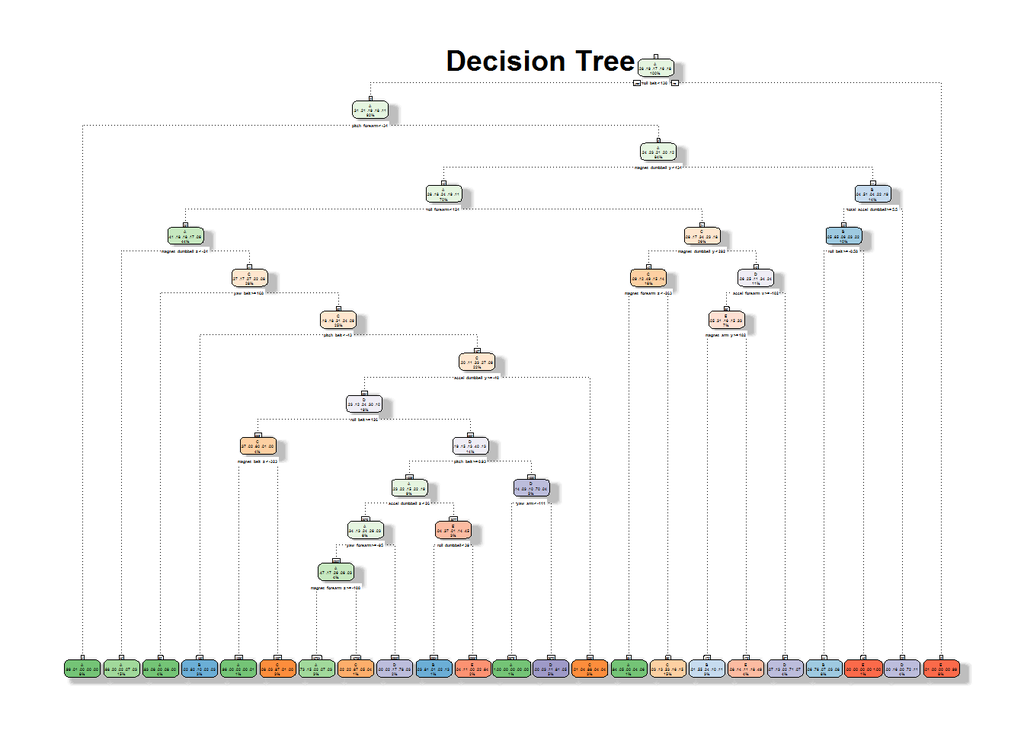

```r
Fit1 <- rpart(classe ~ ., data=subtrain3, method="class")
fancyRpartPlot(Fit1, main="Decision Tree", sub=" ")
```

```r
Fit2 <- randomForest(classe ~. , data=subtrain3)
Fit2
```

```
##
## Call:
##  randomForest(formula = classe ~ ., data = subtrain3)
##                Type of random forest: classification
##                      Number of trees: 500
## No. of variables tried at each split: 7
##
##         OOB estimate of  error rate: 0.77%
## Confusion matrix:
##      A    B    C    D    E class.error
## A 3344    3    0    0    1 0.001194743
## B   17 2254    8    0    0 0.010969724
## C    0   18 2033    3    0 0.010223953
## D    0    0   28 1900    2 0.015544041
## E    0    0    2    9 2154 0.005080831
```

```r
Predict1 <- predict(Fit1, subtest, type = "class")
confusionMatrix(Predict1, subtest$classe)
```

```
## Confusion Matrix and Statistics
##
##           Reference
## Prediction    A    B    C    D    E
##          A 3085  452   47  189   80
##          B   75 1299  176   74  143
##          C   95  283 1673  296  278
##          D   34  148  102 1230  115
##          E   59   97   56  141 1549
##
## Overall Statistics
##
##                Accuracy : 0.7503
##                  95% CI : (0.7424, 0.7581)
##     No Information Rate : 0.2843
##     P-Value [Acc > NIR] : < 2.2e-16
##
##                   Kappa : 0.6826
##  Mcnemar's Test P-Value : < 2.2e-16
##
## Statistics by Class:
##
##                      Class: A Class: B Class: C Class: D Class: E
## Sensitivity            0.9214   0.5700   0.8145   0.6373   0.7155
## Specificity            0.9089   0.9507   0.9021   0.9595   0.9633
## Pos Pred Value         0.8007   0.7351   0.6373   0.7551   0.8144
## Neg Pred Value         0.9668   0.9021   0.9584   0.9310   0.9376
## Prevalence             0.2843   0.1935   0.1744   0.1639   0.1838
## Detection Rate         0.2620   0.1103   0.1421   0.1044   0.1315
## Detection Prevalence   0.3272   0.1501   0.2229   0.1383   0.1615
## Balanced Accuracy      0.9152   0.7604   0.8583   0.7984   0.8394
```

```r
Predict2 <- predict(Fit2, subtest, type = "class")
confusionMatrix(Predict2, subtest$classe)
```

```
## Confusion Matrix and Statistics
##
##           Reference
## Prediction    A    B    C    D    E
##          A 3348    0    0    0    0
##          B    0 2279    0    0    0
##          C    0    0 2054    0    0
##          D    0    0    0 1930    0
##          E    0    0    0    0 2165
##
## Overall Statistics
##
##                Accuracy : 1
##                  95% CI : (0.9997, 1)
##     No Information Rate : 0.2843
##     P-Value [Acc > NIR] : < 2.2e-16
##
##                   Kappa : 1
##  Mcnemar's Test P-Value : NA
##
## Statistics by Class:
##
##                      Class: A Class: B Class: C Class: D Class: E
## Sensitivity            1.0000   1.0000   1.0000   1.0000   1.0000
## Specificity            1.0000   1.0000   1.0000   1.0000   1.0000
## Pos Pred Value         1.0000   1.0000   1.0000   1.0000   1.0000
## Neg Pred Value         1.0000   1.0000   1.0000   1.0000   1.0000
## Prevalence             0.2843   0.1935   0.1744   0.1639   0.1838
## Detection Rate         0.2843   0.1935   0.1744   0.1639   0.1838
## Detection Prevalence   0.2843   0.1935   0.1744   0.1639   0.1838
## Balanced Accuracy      1.0000   1.0000   1.0000   1.0000   1.0000
```

As we decide that Random Forest is the most accurate model we will apply to the final test set

```r
Predict3 <- predict(Fit2, test)
Predict3
```

```
##  1  2  3  4  5  6  7  8  9 10 11 12 13 14 15 16 17 18 19 20
##  B  A  B  A  A  E  D  B  A  A  B  C  B  A  E  E  A  B  B  B
## Levels: A B C D E
```